# Investigators report

2022-12-21 13:26:04

# Purpose

This document creates a report of all of investigators affiliated in some way with Databrary.

## How to generate

1. Source the helper functions (`source("R/helpers.R")`) from the R console.
2. Execute `render_investigators_report(db_login, max_party_id)`, substituting your own Databrary login (email) for `db_login` and the maximum party_id value you want to use to update the institutions database.

# Update investigators

By default, this report updates the local CSV database of investigators from a list of institutions. If you are running the report for the first time, the update may take awhile. If you want to update the list of institutions first, the set `update_inst` to TRUE. Or, if you *do not* want to update the investigator CSV, set the `update_invest_csv` equal to `False` in the call to this report, e.g., `render_investigators_report(db_login, update_invest_csv = 'False')`.

```r
if (params$update_invest_csv) {
  message("Updating CSV investigator database.")
  update_invest_csv(update_inst = FALSE, return_df = FALSE)
  if (params$update_invest_json) {
  export_cleaned_inst_json_from_csv()
  }
} else {
  message("Investigator CSV not updated.")
}

if (params$use_saved_file) {
  message("Using saved CSV file.")
}
```

# Import data

For efficiency reasons, we save a copy of the list of investigators in a CSV and also reload the list when we want to analyze the data.

```r
if (params$use_saved_file) {
  if (file.exists(params$save_fn)) {
    invest_df <- readr::read_csv(params$save_fn, show_col_types = FALSE)
  } else {
    message("File not found.")
  }
}
```

Remove duplicate entries for some AIs.

```r
invest_df <- invest_df %>%
  dplyr::distinct(ai_id, .keep_all = TRUE)
```

# Visualize and summarize

```r
gte2_affils <- invest_df %>%
  dplyr::filter(., n_affils >= 2)

gte5_affils <- invest_df %>%
  dplyr::filter(., n_affils >= 5)

gte10_affils <- invest_df %>%
  dplyr::filter(., n_affils >= 10)

no_affils <- invest_df %>%
  dplyr::filter(., n_affils < 1)
```

Note that there are 19 Authorized Investigators with 10 or more affiliates; 57 with 5 or more; 136 with 2 or more affiliates; and 1334 with no affilates.

## 10+ affiliates

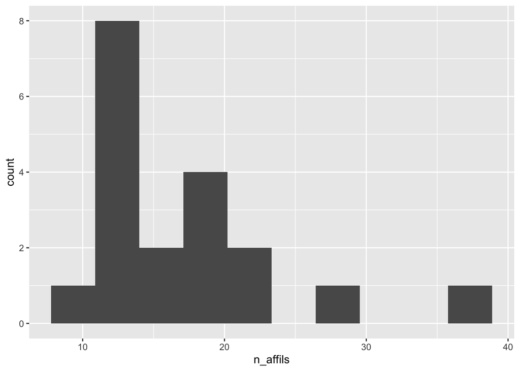

```r
ggplot(gte10_affils) +
  aes(n_affils) +
  geom_histogram(bins = 10)
```

```r
gte10_affils %>%
  dplyr::arrange(., desc(n_affils)) %>%
  dplyr::select(., ai_id, ai_last, ai_first, affiliation, ai_db_url, n_affils) %>%
  kableExtra::kbl(.) %>%
  kableExtra::kable_styling()
```

| ai_id | ai_last | ai_first | affiliation | ai_db_url | n_affils |
| --- | --- | --- | --- | --- | --- |
| 5 | Adolph | Karen | New York University | https://nyu.databrary.org/party/5 | 38 |
| 531 | Goldstein | Thalia R. | George Mason University | https://nyu.databrary.org/party/531 | 28 |
| 538 | Oakes | Lisa | UC Davis | https://nyu.databrary.org/party/538 | 23 |
| 3110 | Reich | Stephanie | University of California, Irvine | https://nyu.databrary.org/party/3110 | 23 |
| 96 | Perez-Edgar | Koraly | The Pennsylvania State University | https://nyu.databrary.org/party/96 | 20 |
| 3044 | Cabrera | Natasha | University of Maryland College Park | https://nyu.databrary.org/party/3044 | 20 |
| 2382 | Berger | Sarah E | College of Staten Island, CUNY | https://nyu.databrary.org/party/2382 | 19 |
| 4945 | Lombardi | Doug | University of Maryland | https://nyu.databrary.org/party/4945 | 18 |
| 650 | Casasola | Marianella | Cornell University | https://nyu.databrary.org/party/650 | 17 |
| 70 | Messinger | Daniel | University of Miami | https://nyu.databrary.org/party/70 | 15 |
| 249 | Buss | Kristin A | The Pennsylvania State University | https://nyu.databrary.org/party/249 | 14 |
| 1913 | Kucker | Sarah | Southern Methodist University | https://nyu.databrary.org/party/1913 | 14 |
| 5032 | Richert | Rebekah | University of California, Riverside | https://nyu.databrary.org/party/5032 | 13 |
| 562 | Weisberg | Deena Skolnick | Villanova University | https://nyu.databrary.org/party/562 | 13 |
| 1117 | Jaswal | Vikram | University of Virginia | https://nyu.databrary.org/party/1117 | 12 |
| 1612 | Corriveau | Kathleen | Boston University | https://nyu.databrary.org/party/1612 | 12 |
| 82 | LoBue | Vanessa | Rutgers University | https://nyu.databrary.org/party/82 | 11 |
| 1197 | Jirout | Jamie | University of Virginia | https://nyu.databrary.org/party/1197 | 11 |
| 104 | Barr | Rachel | Georgetown University | https://nyu.databrary.org/party/104 | 10 |

## 5+ affiliates

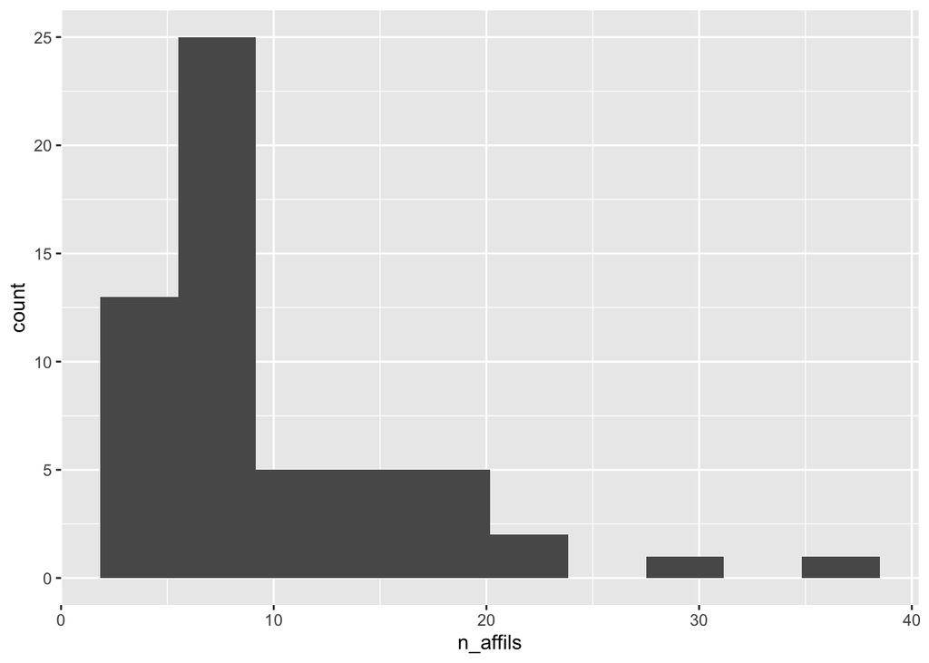

```r
ggplot(gte5_affils) +
  aes(n_affils) +
  geom_histogram(bins = 10)
```

```r
gte5_affils %>%
  dplyr::arrange(., desc(n_affils)) %>%
  dplyr::select(., ai_id, ai_last, ai_first, affiliation, ai_db_url, n_affils) %>%
  kableExtra::kbl(.) %>%
  kableExtra::kable_styling()
```

| ai_id | ai_last | ai_first | affiliation | ai_db_url | n_affils |
| --- | --- | --- | --- | --- | --- |
| 5 | Adolph | Karen | New York University | https://nyu.databrary.org/party/5 | 38 |
| 531 | Goldstein | Thalia R. | George Mason University | https://nyu.databrary.org/party/531 | 28 |
| 538 | Oakes | Lisa | UC Davis | https://nyu.databrary.org/party/538 | 23 |
| 3110 | Reich | Stephanie | University of California, Irvine | https://nyu.databrary.org/party/3110 | 23 |
| 96 | Perez-Edgar | Koraly | The Pennsylvania State University | https://nyu.databrary.org/party/96 | 20 |
| 3044 | Cabrera | Natasha | University of Maryland College Park | https://nyu.databrary.org/party/3044 | 20 |
| 2382 | Berger | Sarah E | College of Staten Island, CUNY | https://nyu.databrary.org/party/2382 | 19 |
| 4945 | Lombardi | Doug | University of Maryland | https://nyu.databrary.org/party/4945 | 18 |
| 650 | Casasola | Marianella | Cornell University | https://nyu.databrary.org/party/650 | 17 |
| 70 | Messinger | Daniel | University of Miami | https://nyu.databrary.org/party/70 | 15 |
| 249 | Buss | Kristin A | The Pennsylvania State University | https://nyu.databrary.org/party/249 | 14 |
| 1913 | Kucker | Sarah | Southern Methodist University | https://nyu.databrary.org/party/1913 | 14 |
| 5032 | Richert | Rebekah | University of California, Riverside | https://nyu.databrary.org/party/5032 | 13 |
| 562 | Weisberg | Deena Skolnick | Villanova University | https://nyu.databrary.org/party/562 | 13 |
| 1117 | Jaswal | Vikram | University of Virginia | https://nyu.databrary.org/party/1117 | 12 |
| 1612 | Corriveau | Kathleen | Boston University | https://nyu.databrary.org/party/1612 | 12 |
| 82 | LoBue | Vanessa | Rutgers University | https://nyu.databrary.org/party/82 | 11 |
| 1197 | Jirout | Jamie | University of Virginia | https://nyu.databrary.org/party/1197 | 11 |
| 104 | Barr | Rachel | Georgetown University | https://nyu.databrary.org/party/104 | 10 |
| 32 | Karasik | Lana | CUNY | https://nyu.databrary.org/party/32 | 9 |
| 2891 | Eisen | Sierra | Wesleyan University | https://nyu.databrary.org/party/2891 | 9 |
| 6 | Gilmore | Rick O. | The Pennsylvania State University | https://nyu.databrary.org/party/6 | 8 |
| 6754 | Wang | Jenny | Rutgers University | https://nyu.databrary.org/party/6754 | 8 |
| 126 | Fausey | Caitlin M. | University of Oregon | https://nyu.databrary.org/party/126 | 8 |
| 258 | Frank | Michael C. | Stanford University | https://nyu.databrary.org/party/258 | 8 |
| 5446 | Wagner | Nicholas | Boston University | https://nyu.databrary.org/party/5446 | 8 |
| 11 | Tamis-LeMonda | Catherine | New York University | https://nyu.databrary.org/party/11 | 7 |
| 1256 | Frank | Jennifer | The Pennsylvania State University | https://nyu.databrary.org/party/1256 | 7 |
| 9020 | Saxbe | Darby | University of Southern California | https://nyu.databrary.org/party/9020 | 7 |
| 1526 | Ossmy | Ori | Birkbeck University of London | https://nyu.databrary.org/party/1526 | 7 |
| 61 | Bergelson | Elika | Duke University | https://nyu.databrary.org/party/61 | 7 |
| 5783 | Lucca | Kelsey | Arizona State University | https://nyu.databrary.org/party/5783 | 7 |
| 8101 | Wilson | Rujuta | University of California, Los Angeles | https://nyu.databrary.org/party/8101 | 7 |
| 2773 | Wojcik | Erica | Skidmore College | https://nyu.databrary.org/party/2773 | 7 |
| 2653 | Scott | Lisa | University of Florida | https://nyu.databrary.org/party/2653 | 7 |
| 244 | Woodward | Amanda | University of Chicago | https://nyu.databrary.org/party/244 | 6 |
| 1228 | Marshall | Peter | Temple University | https://nyu.databrary.org/party/1228 | 6 |
| 334 | Iverson | Jana | University of Pittsburgh | https://nyu.databrary.org/party/334 | 6 |
| 5539 | Bauer | Patricia | Emory University | https://nyu.databrary.org/party/5539 | 6 |
| 376 | Bahrick | Lorraine E. | Florida International University | https://nyu.databrary.org/party/376 | 6 |
| 1371 | Lew-Williams | Casey | Princeton University | https://nyu.databrary.org/party/1371 | 6 |
| 2176 | Harbourne | Regina | Duquesne University | https://nyu.databrary.org/party/2176 | 6 |
| 2581 | Camparo Avila | Daniel | Universidad de la República | https://nyu.databrary.org/party/2581 | 6 |
| 3743 | Ng | Florrie Fei-Yin | The Chinese University of Hong Kong | https://nyu.databrary.org/party/3743 | 6 |
| 277 | Rhodes | Marjorie | New York University | https://nyu.databrary.org/party/277 | 5 |
| 252 | Scherf | Kathryn Suzanne | The Pennsylvania State University | https://nyu.databrary.org/party/252 | 5 |
| 99 | Frick | Janet | University of Georgia | https://nyu.databrary.org/party/99 | 5 |
| 5988 | Diosan | Laura | Babes Bolyai University, Faculty of Mathematics and Computer Science | https://nyu.databrary.org/party/5988 | 5 |
| 3517 | Curenton | Stephanie Michelle | Boston University | https://nyu.databrary.org/party/3517 | 5 |
| 8771 | Sandhofer | Catherine | UCLA | https://nyu.databrary.org/party/8771 | 5 |
| 314 | Blumberg | Mark | University of Iowa | https://nyu.databrary.org/party/314 | 5 |
| 4605 | Froemke | Robert | NYU School of Medicine | https://nyu.databrary.org/party/4605 | 5 |
| 2095 | Sullivan | Jessica | Skidmore College | https://nyu.databrary.org/party/2095 | 5 |
| 384 | Lee | Do Kyeong | California State University Fullerton | https://nyu.databrary.org/party/384 | 5 |
| 7217 | Sen | Hilal | MEF UNIVERSITY | https://nyu.databrary.org/party/7217 | 5 |
| 7537 | Zhao | Xin | East China Normal University | https://nyu.databrary.org/party/7537 | 5 |
| 9526 | Nelson | Nicole L | University of Adelaide | https://nyu.databrary.org/party/9526 | 5 |

## 2+ affiliates

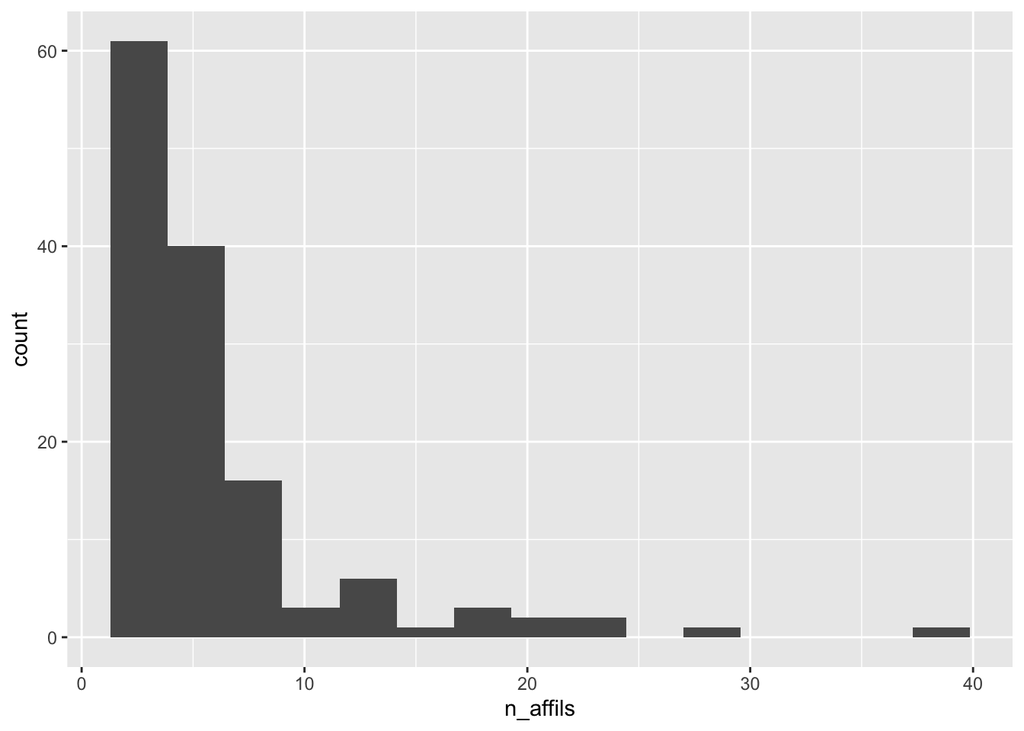

```r
ggplot(gte2_affils) +
  aes(n_affils) +
  geom_histogram(bins = 15)
```

```r
gte2_affils %>%
  dplyr::arrange(., desc(n_affils)) %>%
  dplyr::select(., ai_id, ai_last, ai_first, affiliation, ai_db_url, n_affils) %>%
  kableExtra::kbl(.) %>%
  kableExtra::kable_styling()
```

| ai_id | ai_last | ai_first | affiliation | ai_db_url | n_affils |
| --- | --- | --- | --- | --- | --- |
| 5 | Adolph | Karen | New York University | https://nyu.databrary.org/party/5 | 38 |
| 531 | Goldstein | Thalia R. | George Mason University | https://nyu.databrary.org/party/531 | 28 |
| 538 | Oakes | Lisa | UC Davis | https://nyu.databrary.org/party/538 | 23 |
| 3110 | Reich | Stephanie | University of California, Irvine | https://nyu.databrary.org/party/3110 | 23 |
| 96 | Perez-Edgar | Koraly | The Pennsylvania State University | https://nyu.databrary.org/party/96 | 20 |
| 3044 | Cabrera | Natasha | University of Maryland College Park | https://nyu.databrary.org/party/3044 | 20 |
| 2382 | Berger | Sarah E | College of Staten Island, CUNY | https://nyu.databrary.org/party/2382 | 19 |
| 4945 | Lombardi | Doug | University of Maryland | https://nyu.databrary.org/party/4945 | 18 |
| 650 | Casasola | Marianella | Cornell University | https://nyu.databrary.org/party/650 | 17 |
| 70 | Messinger | Daniel | University of Miami | https://nyu.databrary.org/party/70 | 15 |
| 249 | Buss | Kristin A | The Pennsylvania State University | https://nyu.databrary.org/party/249 | 14 |
| 1913 | Kucker | Sarah | Southern Methodist University | https://nyu.databrary.org/party/1913 | 14 |
| 5032 | Richert | Rebekah | University of California, Riverside | https://nyu.databrary.org/party/5032 | 13 |
| 562 | Weisberg | Deena Skolnick | Villanova University | https://nyu.databrary.org/party/562 | 13 |
| 1117 | Jaswal | Vikram | University of Virginia | https://nyu.databrary.org/party/1117 | 12 |
| 1612 | Corriveau | Kathleen | Boston University | https://nyu.databrary.org/party/1612 | 12 |
| 82 | LoBue | Vanessa | Rutgers University | https://nyu.databrary.org/party/82 | 11 |
| 1197 | Jirout | Jamie | University of Virginia | https://nyu.databrary.org/party/1197 | 11 |
| 104 | Barr | Rachel | Georgetown University | https://nyu.databrary.org/party/104 | 10 |
| 32 | Karasik | Lana | CUNY | https://nyu.databrary.org/party/32 | 9 |
| 2891 | Eisen | Sierra | Wesleyan University | https://nyu.databrary.org/party/2891 | 9 |
| 6 | Gilmore | Rick O. | The Pennsylvania State University | https://nyu.databrary.org/party/6 | 8 |
| 6754 | Wang | Jenny | Rutgers University | https://nyu.databrary.org/party/6754 | 8 |
| 126 | Fausey | Caitlin M. | University of Oregon | https://nyu.databrary.org/party/126 | 8 |
| 258 | Frank | Michael C. | Stanford University | https://nyu.databrary.org/party/258 | 8 |
| 5446 | Wagner | Nicholas | Boston University | https://nyu.databrary.org/party/5446 | 8 |
| 11 | Tamis-LeMonda | Catherine | New York University | https://nyu.databrary.org/party/11 | 7 |
| 1256 | Frank | Jennifer | The Pennsylvania State University | https://nyu.databrary.org/party/1256 | 7 |
| 9020 | Saxbe | Darby | University of Southern California | https://nyu.databrary.org/party/9020 | 7 |
| 1526 | Ossmy | Ori | Birkbeck University of London | https://nyu.databrary.org/party/1526 | 7 |

[output cut: 106 more lines]

## All

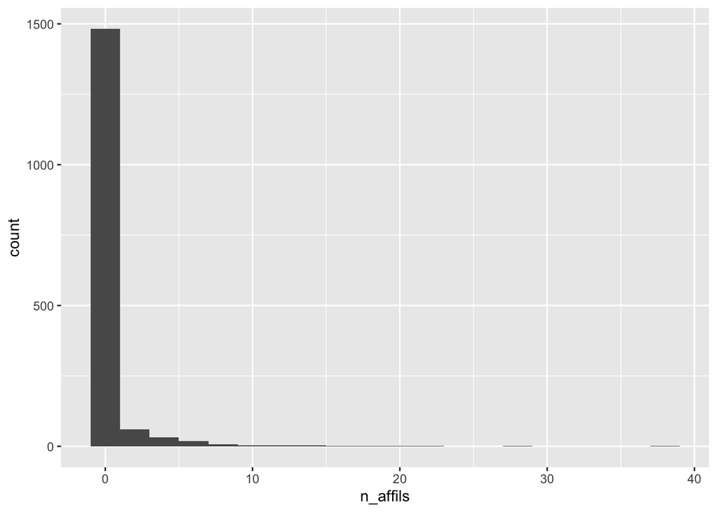

```r
ggplot(invest_df) +
  aes(n_affils) +
  geom_histogram(bins = 20)
```

```r
invest_df %>%
  dplyr::arrange(., desc(n_affils)) %>%
  dplyr::select(., ai_id, ai_last, ai_first, affiliation, ai_db_url, n_affils) %>%
  kableExtra::kbl(.) %>%
  kableExtra::kable_styling()
```

| ai_id | ai_last | ai_first | affiliation | ai_db_url | n_affils |
| --- | --- | --- | --- | --- | --- |
| 5 | Adolph | Karen | New York University | https://nyu.databrary.org/party/5 | 38 |
| 531 | Goldstein | Thalia R. | George Mason University | https://nyu.databrary.org/party/531 | 28 |
| 538 | Oakes | Lisa | UC Davis | https://nyu.databrary.org/party/538 | 23 |
| 3110 | Reich | Stephanie | University of California, Irvine | https://nyu.databrary.org/party/3110 | 23 |
| 96 | Perez-Edgar | Koraly | The Pennsylvania State University | https://nyu.databrary.org/party/96 | 20 |
| 3044 | Cabrera | Natasha | University of Maryland College Park | https://nyu.databrary.org/party/3044 | 20 |
| 2382 | Berger | Sarah E | College of Staten Island, CUNY | https://nyu.databrary.org/party/2382 | 19 |
| 4945 | Lombardi | Doug | University of Maryland | https://nyu.databrary.org/party/4945 | 18 |
| 650 | Casasola | Marianella | Cornell University | https://nyu.databrary.org/party/650 | 17 |
| 70 | Messinger | Daniel | University of Miami | https://nyu.databrary.org/party/70 | 15 |
| 249 | Buss | Kristin A | The Pennsylvania State University | https://nyu.databrary.org/party/249 | 14 |
| 1913 | Kucker | Sarah | Southern Methodist University | https://nyu.databrary.org/party/1913 | 14 |
| 5032 | Richert | Rebekah | University of California, Riverside | https://nyu.databrary.org/party/5032 | 13 |
| 562 | Weisberg | Deena Skolnick | Villanova University | https://nyu.databrary.org/party/562 | 13 |
| 1117 | Jaswal | Vikram | University of Virginia | https://nyu.databrary.org/party/1117 | 12 |
| 1612 | Corriveau | Kathleen | Boston University | https://nyu.databrary.org/party/1612 | 12 |
| 82 | LoBue | Vanessa | Rutgers University | https://nyu.databrary.org/party/82 | 11 |
| 1197 | Jirout | Jamie | University of Virginia | https://nyu.databrary.org/party/1197 | 11 |
| 104 | Barr | Rachel | Georgetown University | https://nyu.databrary.org/party/104 | 10 |
| 32 | Karasik | Lana | CUNY | https://nyu.databrary.org/party/32 | 9 |
| 2891 | Eisen | Sierra | Wesleyan University | https://nyu.databrary.org/party/2891 | 9 |
| 6 | Gilmore | Rick O. | The Pennsylvania State University | https://nyu.databrary.org/party/6 | 8 |
| 6754 | Wang | Jenny | Rutgers University | https://nyu.databrary.org/party/6754 | 8 |
| 126 | Fausey | Caitlin M. | University of Oregon | https://nyu.databrary.org/party/126 | 8 |
| 258 | Frank | Michael C. | Stanford University | https://nyu.databrary.org/party/258 | 8 |
| 5446 | Wagner | Nicholas | Boston University | https://nyu.databrary.org/party/5446 | 8 |
| 11 | Tamis-LeMonda | Catherine | New York University | https://nyu.databrary.org/party/11 | 7 |
| 1256 | Frank | Jennifer | The Pennsylvania State University | https://nyu.databrary.org/party/1256 | 7 |
| 9020 | Saxbe | Darby | University of Southern California | https://nyu.databrary.org/party/9020 | 7 |
| 1526 | Ossmy | Ori | Birkbeck University of London | https://nyu.databrary.org/party/1526 | 7 |

[output cut: 1589 more lines]